# Regression models course project

## Executive summary

*Is an automatic or manual transmission better for MPG*

*Quantify the MPG difference between automatic and manual transmissions*

## Exploratory analysis of the data

We start with loading the data and doing some basic summary.

```r
library(datasets)
head(mtcars, 3)
```

```
##                mpg cyl disp  hp drat    wt  qsec vs am gear carb
## Mazda RX4     21.0   6  160 110 3.90 2.620 16.46  0  1    4    4
## Mazda RX4 Wag 21.0   6  160 110 3.90 2.875 17.02  0  1    4    4
## Datsun 710    22.8   4  108  93 3.85 2.320 18.61  1  1    4    1
```

```r
str(mtcars)
```

```
## 'data.frame':    32 obs. of  11 variables:
##  $ mpg : num  21 21 22.8 21.4 18.7 18.1 14.3 24.4 22.8 19.2 ...
##  $ cyl : num  6 6 4 6 8 6 8 4 4 6 ...
##  $ disp: num  160 160 108 258 360 ...
##  $ hp  : num  110 110 93 110 175 105 245 62 95 123 ...
##  $ drat: num  3.9 3.9 3.85 3.08 3.15 2.76 3.21 3.69 3.92 3.92 ...
##  $ wt  : num  2.62 2.88 2.32 3.21 3.44 ...
##  $ qsec: num  16.5 17 18.6 19.4 17 ...
##  $ vs  : num  0 0 1 1 0 1 0 1 1 1 ...
##  $ am  : num  1 1 1 0 0 0 0 0 0 0 ...
##  $ gear: num  4 4 4 3 3 3 3 4 4 4 ...
##  $ carb: num  4 4 1 1 2 1 4 2 2 4 ...
```

## Do automatic and manual transmission cars differ in mpg use?

We are interested in whether the mpg differes by type of transmission (manual vs. automatic). We draw a boxplot showing the mean mpg by type of transmission. The average mpg for automatic transmission is about 17, and for manual transmission about 25.

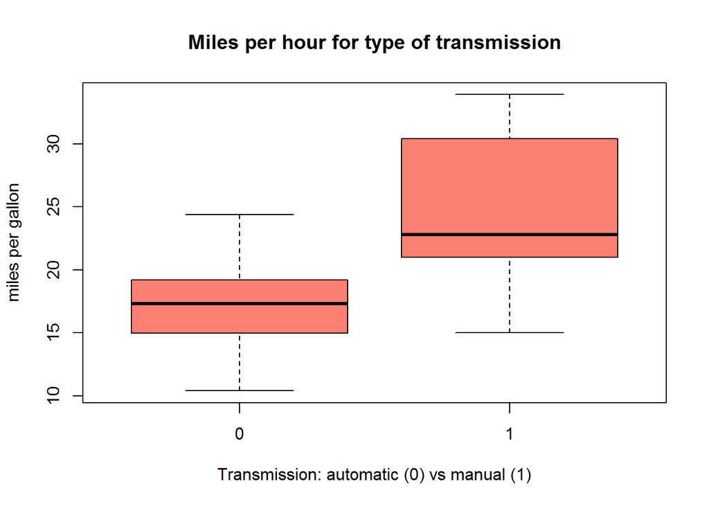

```r
boxplot(mpg~am, data=mtcars, col="salmon", xlab="Transmission: automatic (0) vs manual (1)", ylab="miles per gallon", main="Miles per hour for type of transmission")
```

A t-test for the difference in means has been performed (see Appendix).The p-value of the null hypothesis (of equal means) is 0.001374, so wemreject the null and infer that the mean mpg significantly differs between the two groups.

## Which variables could explain mpg?

The most difficult part is to pick the appropriate variable (other than the transmission type) that we will include in our model. We draw pairwise graphs between mpg and a number of variables that we believe could affect it. We also preset a function (function taken from the pairs Help page), which calculates to correlation between the variables. See the Appendix for the syntax of the function and all the graphs. The variables with highest correlation with mpg are *weight(wt)* and *number of cylinders(cyl)*.

## Regression analysis

We already have our candidates for variables to include in the regression model. To see whether it is indeed the most appropriate one, we will fit a few models and compare how they perform.

We start with a simple model, fitting mpg only with the type of transmission. Then, we add the weight and cylinders and compare how that one is performing. However, after performing other exploratory analysis, we realised that the weight variable differes across transmission types. See the Appendix for very illustrative ggplot and for a t-test for difference in means. The t-test indeed showed that the weight across the two types is signifantly different. Therefore, a final model we will consider is one interacting the weight with the transmission type.

```r
fit1<-lm(mpg~factor(am), data=mtcars)
summary(fit1)$coef
```

```
##              Estimate Std. Error   t value     Pr(>|t|)
## (Intercept) 17.147368   1.124603 15.247492 1.133983e-15
## factor(am)1  7.244939   1.764422  4.106127 2.850207e-04
```

```r
#second model
fit2<-lm(mpg~wt+factor(am)+factor(cyl), data=mtcars)
summary(fit2)$coef
```

```
##                Estimate Std. Error    t value     Pr(>|t|)
## (Intercept)  33.7535920  2.8134831 11.9970836 2.495549e-12
## wt           -3.1495978  0.9080495 -3.4685309 1.770987e-03
## factor(am)1   0.1501031  1.3002231  0.1154441 9.089474e-01
## factor(cyl)6 -4.2573185  1.4112394 -3.0167231 5.514697e-03
## factor(cyl)8 -6.0791189  1.6837131 -3.6105432 1.227964e-03
```

```r
#third model
fit3<-lm(mpg~wt+factor(am)+wt*factor(am)+factor(cyl), data=mtcars)
summary(fit3)$coef
```

```
##                 Estimate Std. Error   t value     Pr(>|t|)
## (Intercept)    29.774836  2.8403415 10.482836 7.870715e-11
## wt             -2.398713  0.8439884 -2.842116 8.603904e-03
## factor(am)1    11.568790  4.0877912  2.830083 8.853842e-03
## factor(cyl)6   -2.709777  1.3573517 -1.996370 5.646509e-02
## factor(cyl)8   -4.776110  1.5558306 -3.069814 4.964603e-03
## wt:factor(am)1 -4.067981  1.3974151 -2.911075 7.295503e-03
```

To test whether adding additional terms is necessary, we used ANOVA likelihood ratio test for nested models. The output is given below. The conclusion from the ANova test is that adding the variables is appropriate.

```r
anova(fit1, fit2, fit3)
```

```
## Analysis of Variance Table
##
## Model 1: mpg ~ factor(am)
## Model 2: mpg ~ wt + factor(am) + factor(cyl)
## Model 3: mpg ~ wt + factor(am) + wt * factor(am) + factor(cyl)
##   Res.Df    RSS Df Sum of Sq       F    Pr(>F)
## 1     30 720.90
## 2     27 182.97  3    537.93 33.7850 4.031e-09 ***
## 3     26 137.99  1     44.98  8.4744  0.007296 **
## ---
## Signif. codes:  0 '***' 0.001 '**' 0.01 '*' 0.05 '.' 0.1 ' ' 1
```

## Some robustness tests

Finally, to perform some robustness analysis on the model we chose. We did the following (see the Appendix for code and graphs):

Plotting the fitted valued and the residuals failed to display some pattern.

Normall Q-Q plot indicates the residuals are normally distributed, as we see no large deviations from the line.

The Scale-Location does not appear problematic.

Finally, residuals versus Leverage does not show the presence of outliers.

## Appendix

T-test for difference of means between manual and automatic

```r
t.test(mtcars$mpg~mtcars$am)
```

```
##
##  Welch Two Sample t-test
##
## data:  mtcars$mpg by mtcars$am
## t = -3.7671, df = 18.332, p-value = 0.001374
## alternative hypothesis: true difference in means is not equal to 0
## 95 percent confidence interval:
##  -11.280194  -3.209684
## sample estimates:
## mean in group 0 mean in group 1
##        17.14737        24.39231
```

A code for function that in the upper panel of pairwise plots, writes the correlations between the respective variables (note, this code was in the *pairs Help page* but was useful to use in our context).The code is followed by some paired plots between mpg and other variables. For better visibility, we plot mpg with only 2 other variables at a time, though it is, of course, possible to draw the relationships between all simultaneously.

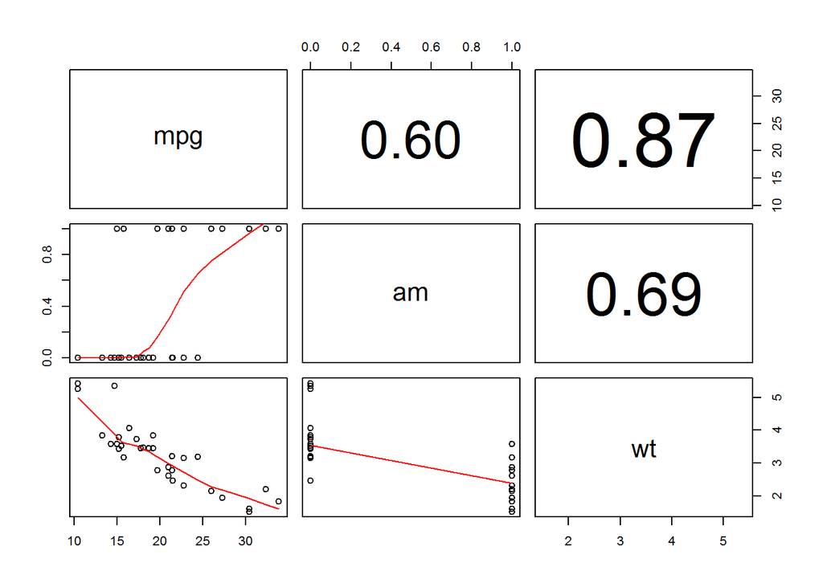

```r
panel.cor <- function(x, y, digits=2, prefix="", cex.cor)
{
    usr <- par("usr"); on.exit(par(usr))
    par(usr = c(0, 1, 0, 1))
    r <- abs(cor(x, y))
    txt <- format(c(r, 0.123456789), digits=digits)[1]
    txt <- paste(prefix, txt, sep="")
    if(missing(cex.cor)) cex <- 0.8/strwidth(txt)
    text(0.5, 0.5, txt, cex = cex * r)
}
pairs(mpg~am+wt, data=mtcars, lower.panel=panel.smooth, upper.panel=panel.cor)
```

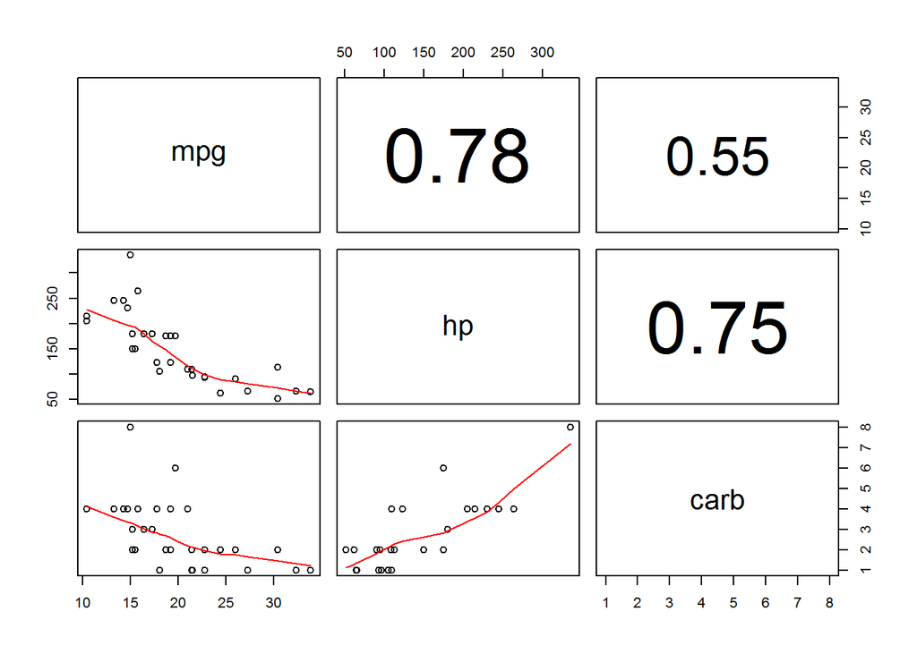

```r
pairs(mpg~hp+carb, data=mtcars, lower.panel=panel.smooth, upper.panel=panel.cor)
```

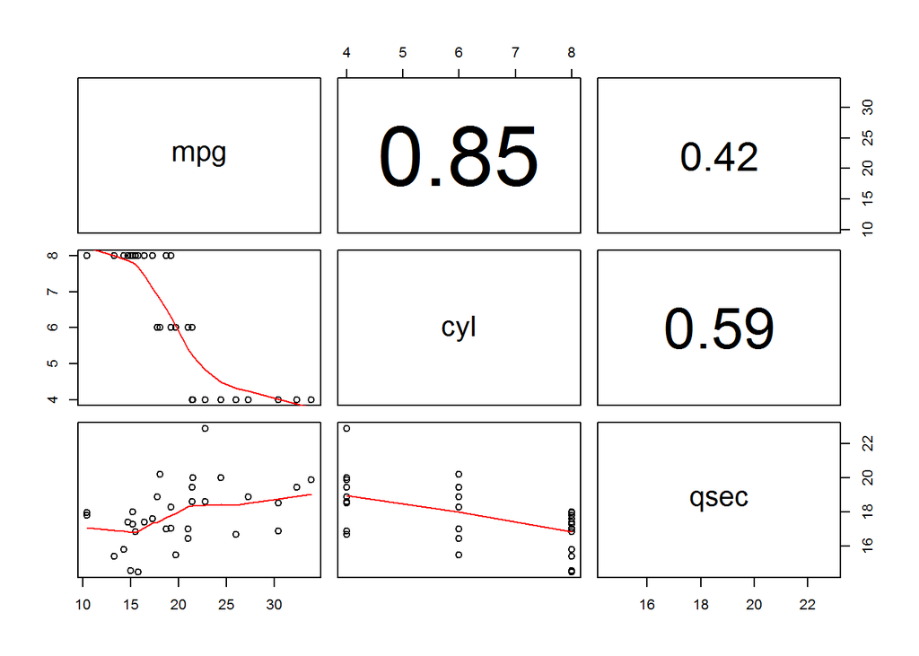

```r
pairs(mpg~cyl+qsec, data=mtcars, lower.panel=panel.smooth, upper.panel=panel.cor)
```

### Weight differences in automatic and manual transmission cars

```r
t.test(mtcars$wt~mtcars$am)
```

```
##
##  Welch Two Sample t-test
##
## data:  mtcars$wt by mtcars$am
## t = 5.4939, df = 29.234, p-value = 6.272e-06
## alternative hypothesis: true difference in means is not equal to 0
## 95 percent confidence interval:
##  0.8525632 1.8632262
## sample estimates:
## mean in group 0 mean in group 1
##        3.768895        2.411000
```

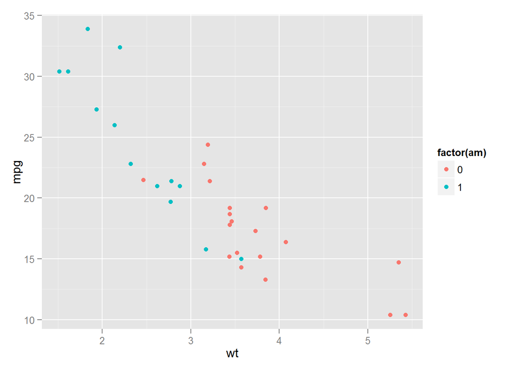

```r
#Graphing them
library(ggplot2)
ggplot(mtcars, aes(wt, mpg, color=factor(am)))+geom_point()
```

### Residuals

Residual plots

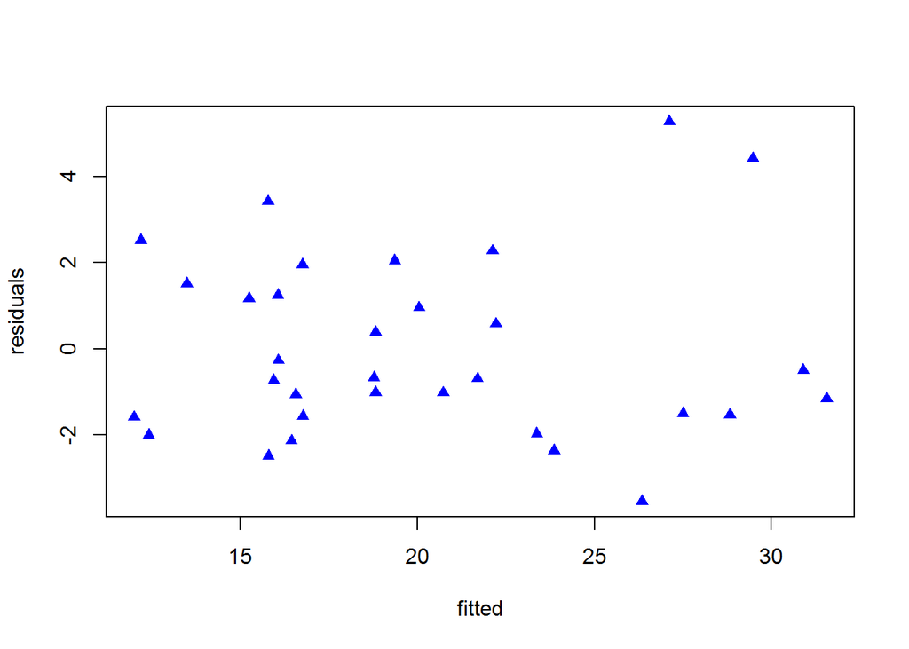

```r
plot(fit3$fitted, fit3$res, col="blue", pch=17, ylab="residuals", xlab="fitted")
```

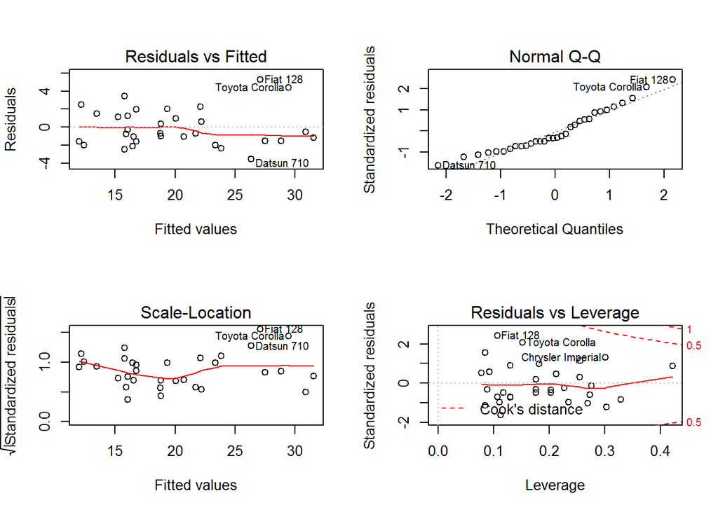

```r
#Overall residual plots
par(mfrow=c(2,2))
plot(fit3)
```

[output not shown]